# Detecting extrema with GAMs

Eric Pedersen

September 22, 2017

This code is to test how effective using a combination of penalized regression with `mgcv` and a test based on the estimated derivatives from the smooth term does in estimating whether a given data set has a “U” shape (with an interior maxima or minima), and seeing how well this test can tell a maxima/minima from just a region where the curve has flattened out. This was inspired by the work at [Data Colada](http://datacolada.org/62), using split linear regression to test for extrema. I wanted to see how effective a GAM would be for this purpose.

I’m relying on the `mgcv` package for fitting smooth terms, and the `dplyr` package for working with more complicated data frame manipulation.

```r
library(dplyr)
library(mgcv)

#You need the multivariate normal RNG from the MASS package
mvrnorm = MASS::mvrnorm
```

```r
# Functions to calculate the 1st and 2nd derivatives of a given time series with
# a given step size. Uses two-point approximations for both 1st and 2nd derivs.
calc_1st_deriv = function(y,delta) (lead(y,1) - lag(y,1))/(2*delta)
calc_2nd_deriv = function(y,delta) (lead(y,1) + lag(y,1)-2*y)/delta^2
```

This next function defines the test for peaks from the data. It requires you to pass it two nx2 matrices: the first one is the confidence intervals for the first derivatives of all evaluated points. the second matrix is the same for the second derivatives.

I’ve implemented two separate tests for peaks: the two-derivative test (`test="two-deriv"`) and the crossing test (`test="crossing"`). The first test assumes a given point is a candidate peak if the confidence interval for the first derivative of that point includes zero and the CI for the 2nd derivative does not. The second test defines a set of points as candidates if all the CIs for the first derivative include zero and the first significant points at the start and end of the interval have first derivatives of opposite signs (this rules out maxima at the ends of the range, or places where the function increases (decreases), pauses for a while, then continues increasing (decreasing).

```r
# Function to test if each the confidence intervals for the derivatives of a
# given curve sastisfy the test for a point potentially being an extremum The
# first deriv critera determines if the confidence intervals for the first
# derivative at a given point overlaps zero. The second deriv criteria tests if
# the second deriv CI overlaps zero. A point is only considered to be a
# candidate extremum if the first criteria is true and the second is false
find_peaks = function(deriv_1_bounds,
                      deriv_2_bounds,
                      test = c("two-deriv","crossing")){

  stopifnot(nrow(deriv_1_bounds)==nrow(deriv_2_bounds))
  stopifnot(ncol(deriv_1_bounds)==2&ncol(deriv_2_bounds)==2)

  n_vals = nrow(deriv_1_bounds)

  # calculate the sign of the derivatives. If both ends of the interval are pos/neg
  # at a point, this will return a value of +1/-1 for that point. It will be zero
  # iff the CI overlaps zero at that point.
  deriv1_sign = (sign(deriv_1_bounds[,1]) + sign(deriv_1_bounds[,2]))/2
  deriv2_sign  = (sign(deriv_2_bounds[,1]) + sign(deriv_2_bounds[,2]))/2

  #Derivative series start with na values
  #This removes that issue (to prevent a run of na values)
  deriv1_sign[c(1,n_vals)] = deriv1_sign[c(2, n_vals-1)]
  deriv2_sign[c(1,n_vals)] = deriv2_sign[c(2, n_vals-1)]

  if(test[1]=="two-deriv"){
    is_candidate = (deriv1_sign==0)&(deriv2_sign!=0)
  }else if(test[1] =="crossing"){
    deriv1_runs = rle(deriv1_sign)
    n_runs = length(deriv1_runs$lengths)
    deriv1_run_start = c(1, cumsum(deriv1_runs$lengths)[-n_runs]+1)
    deriv1_run_end = cumsum(deriv1_runs$lengths)
    deriv1_run_sign = deriv1_runs$values
    is_candidate = rep(FALSE, times=nrow(deriv_1_bounds))
    for(i in 1:n_runs){
      if(i>1&i<n_runs & deriv1_run_sign[i]==0){
        if(deriv1_sign[deriv1_run_start[i-1]]*deriv1_sign[deriv1_run_end[i+1]]==-1){
          is_candidate[deriv1_run_start[i]:deriv1_run_end[i]] = TRUE
        }
      }
    }
  }else {
    stop("this is not an implemented test")
  }
  is_candidate
}
```

Now I’ll simulate some random data to test this. I’m assuming that the true function is a log curve up to a break point, then has a zero or negative slope from that point on. I also assume x ranges between 0.1 and 4.

```r
set.seed(46)


# function for generating underlying curve. Simple sum of a log-curve and a
# quadratic parameters a,b determine how large the log and quadratic components
# are, mid determines where the center of the quadratic is
fit_func = function(x, a,b,mid)  ifelse(x<mid, a*log(x), a*log(mid) -b*(x-mid))

n = 100         # number of data points
sigma = 1           # st. dev. of errors around mean value

#Parmaters determining how large the range of x is
low_lim = 0.1
high_lim =4

# parameters for the true function
a   = 1
b   = 0.2
mid = 2


# data frame with x, values, random y values, and the true curve
training_data = data_frame(x = seq(low_lim,high_lim, length=n),
                           y= rnorm(n,fit_func(x,a,b,mid),sigma),
                           true_val = fit_func(x,a,b,mid) )
```

Using the training data, I fitted a GAM with 20 basis functions, and m=3 to penalize squared third derivatives. The number of basis functions isn’t that important, as long as it’s large enough for mgcv’s penalty estimation function to work, but if m<3, it becomes difficult to estimate the second derivative (basically, because new random functions drawn from the model posterior will have very wiggly 2nd derivatives).

```r
# The fitted model, usig a 20 basis function thin plate spline smoother with
# REML fitting criteria. m=3 specifies that the model should penalize squard
# third derivatives. This is important as if m=2 (the default) then prior
# simulations from the fit are too wiggly, and end up with too wide a range of
# 2nd derivatives
mod = gam(y~s(x, bs= "tp", k=20,m = 3), data=training_data,method="REML")
```

Using this model, and new data spread across a gradient, I simulated 500 new functions from the model posterior, and estimated the first and second derivatives for each point for each simulation. Using all of these, I estimated median and 95% CI for the derivatives at each point.

```r
# step size used for calculating derivatives
step_size = 0.01

# The test data, with one x per step unit across the range.
test_data = data_frame(x=seq(low_lim, high_lim,by= step_size))

#Simulate new functions from the posterior distribution of functions, using the
#test data and 500 simulations
n_sims = 500
mod_coef = coef(mod) # mean values for all basis functions
mod_vcov =vcov(mod)  # posterior variance-covariance matrix
mod_sims = mvrnorm(n_sims, mod_coef,mod_vcov) #random parameter draws
test_lp = predict.gam(mod,newdata = test_data,type = "lpmatrix") #the basis functions
test_sims = test_lp %*% t(mod_sims) #random parameters times basis functions

test = "crossing" #change this to "two-deriv" to check the alternate test

#Calculates estimated first and second derivatives
test_1st_deriv = apply(test_sims,MARGIN = 2,calc_1st_deriv, delta= step_size)
test_2nd_deriv = apply(test_sims,MARGIN = 2,calc_2nd_deriv, delta= step_size)


# 95% confidence intervals for the function, 1st, and 2nd derivatives
test_CI = t(apply(test_sims,
                  MARGIN = 1,
                  FUN = quantile,
                  probs=c(0.025,0.5,0.975),
                  na.rm=T))
test_1st_deriv_CI = t(apply(test_1st_deriv ,
                            MARGIN = 1,
                            FUN = quantile,
                            probs=c(0.025,0.5,0.975),
                            na.rm=T))
test_2nd_deriv_CI = t(apply(test_2nd_deriv ,
                            MARGIN = 1,
                            FUN = quantile,
                            probs=c(0.025,0.5, 0.975),
                            na.rm=T))
```

Using these derivatives, I tested for peaks. The plots below highlight the candidate region selected by the test as extrema in red (if the test found any regions).

```r
# Using the CIs for 1st and 2nd derivatives to test for peaks
candidate_peaks = as.vector(find_peaks(test_1st_deriv_CI[,c(1,3)],
                                       test_2nd_deriv_CI[,c(1,3)],
                                       test = test))

candidate_peaks = ifelse(is.na(candidate_peaks), F, candidate_peaks)
```

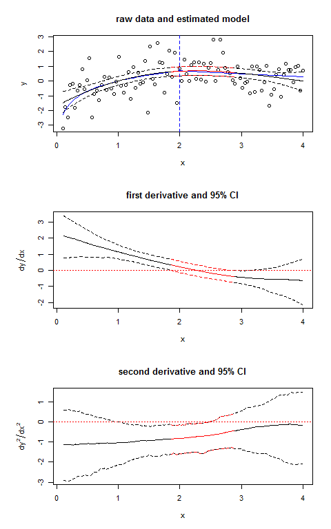

```r
par(mfrow=c(3,1),mar=c(5, 6, 4, 2) + 0.1)

# Plot of raw data and model fit, with true function in blue and
# estimated minima in red. Vertical blue line is the true minimum
plot(y~x, data= training_data, main="raw data and estimated model")
points(true_val~x, data=training_data, col="blue",type="l",lwd=1)
matplot(test_data$x, test_CI,type="l",col="black",lty=c(2,1,2),add = T)
if(any(candidate_peaks)){
  matplot(test_data$x[candidate_peaks], test_CI[candidate_peaks,],
          type="l",col="red",lty=c(2,1,2),add = T)
}
abline(v= mid, col="blue",lty=2)


#plot of first derivatives plus CI
matplot(test_data$x,test_1st_deriv_CI,
        type="l",
        col="black",
        lty=c(2,1,2),
        main="first derivative and 95% CI",
        xlab = "x",
        ylab=expression(dy/dx))
if(any(candidate_peaks)){
  matplot(test_data$x[candidate_peaks],
          test_1st_deriv_CI[candidate_peaks,],
          type="l",col="red",lty=c(2,1,2),add = T)
}
abline(h=0,lty=3,col="red")

#Plot of estimated 2nd derivative plus CI
matplot(test_data$x,test_2nd_deriv_CI,type="l",
        col="black",lty=c(2,1,2),
        main="second derivative and 95% CI",
        xlab = "x",
        ylab=expression(dy^2/dx^2))
if(any(candidate_peaks)){
  matplot(test_data$x[candidate_peaks],
          test_2nd_deriv_CI[candidate_peaks,],
          type="l",col="red",lty=c(2,1,2),add = T)
}
abline(h=0, lty=3, col="red")
```